# Trauma_hw_Sotnikov

Bogdan Sotnikov

2023-10-21

# Глава 1. Технические моменты.

## Читаем данные

```r
trauma <- read_excel("./trauma.xlsx")
head(trauma)
```

```
## # A tibble: 6 × 13
##   ...1     id Name       Sex     Age Height Weight   SBP   DBP  FOUR   GSC    Hb
##   <chr> <dbl> <chr>      <chr> <dbl> <chr>   <dbl> <dbl> <dbl> <dbl> <dbl> <dbl>
## 1 1         1 Jecelle O… Fema…    24 "68\""   176    102    78    10     8  11.4
## 2 2         2 Halie Mcc… Fema…    35 "69.8…   184.   116    86     9     7  12.2
## 3 3         3 Kole Cook  Male     39 "72.8…   210.   122   102    12    12  15
## 4 4         4 Patricia … Fema…    20 "70.5…   195.   120   100    11     9  12.2
## 5 5         5 Grace Cre… Fema…    63 "66.8…   169    112    84     9     7  12.4
## 6 6         6 Joseph Be… Male     60 "72.4…   202.   118    88    13    11  15
## # ℹ 1 more variable: Death <dbl>
```

## Смотрим сводку

```r
str(trauma)
```

```
## tibble [1,024 × 13] (S3: tbl_df/tbl/data.frame)
##  $ ...1  : chr [1:1024] "1" "2" "3" "4" ...
##  $ id    : num [1:1024] 1 2 3 4 5 6 7 8 9 10 ...
##  $ Name  : chr [1:1024] "Jecelle Oberly" "Halie Mccone" "Kole Cook" "Patricia Davis" ...
##  $ Sex   : chr [1:1024] "Female" "Female" "Male" "Female" ...
##  $ Age   : num [1:1024] 24 35 39 20 63 60 63 26 20 25 ...
##  $ Height: chr [1:1024] "68\"" "69.8\"" "72.8\"" "70.5\"" ...
##  $ Weight: num [1:1024] 176 184 210 195 169 ...
##  $ SBP   : num [1:1024] 102 116 122 120 112 118 122 114 104 106 ...
##  $ DBP   : num [1:1024] 78 86 102 100 84 88 100 94 84 78 ...
##  $ FOUR  : num [1:1024] 10 9 12 11 9 13 10 11 10 7 ...
##  $ GSC   : num [1:1024] 8 7 12 9 7 11 9 10 9 5 ...
##  $ Hb    : num [1:1024] 11.4 12.2 15 12.2 12.4 15 11.8 14.4 11.4 12.2 ...
##  $ Death : num [1:1024] 1 0 0 0 1 0 0 0 0 1 ...
```

Нет нужды в переменной `...1`. Также я сомневаюсь, что рост должен быть строковой переменной (необходимо проверить на наличие экзотических записей). Соображение на основании пояснительной нотации к данным – перевести рост и массу к единицам системы СИ. Смерть переводим в факторную переменную.

```r
summary(trauma)
```

```
##      ...1                 id             Name               Sex
##  Length:1024        Min.   :   1.0   Length:1024        Length:1024
##  Class :character   1st Qu.: 256.8   Class :character   Class :character
##  Mode  :character   Median : 512.5   Mode  :character   Mode  :character
##                     Mean   : 512.5
##                     3rd Qu.: 768.2
##                     Max.   :1024.0
##       Age           Height              Weight           SBP
##  Min.   :18.00   Length:1024        Min.   :133.3   Min.   : 90.0
##  1st Qu.:29.00   Class :character   1st Qu.:181.7   1st Qu.:106.0
##  Median :41.00   Mode  :character   Median :193.9   Median :110.0
##  Mean   :40.94                      Mean   :193.5   Mean   :110.8
##  3rd Qu.:53.00                      3rd Qu.:205.4   3rd Qu.:116.0
##  Max.   :64.00                      Max.   :253.1   Max.   :134.0
##       DBP              FOUR             GSC               Hb
##  Min.   : 58.00   Min.   : 0.000   Min.   : 3.000   Min.   : 0.0
##  1st Qu.: 78.00   1st Qu.: 7.000   1st Qu.: 6.000   1st Qu.:12.0
##  Median : 84.00   Median : 9.000   Median : 8.000   Median :13.1
##  Mean   : 84.78   Mean   : 8.853   Mean   : 7.785   Mean   :12.8
##  3rd Qu.: 90.00   3rd Qu.:11.000   3rd Qu.:10.000   3rd Qu.:14.0
##  Max.   :110.00   Max.   :16.000   Max.   :14.000   Max.   :16.2
##      Death
##  Min.   :0.0000
##  1st Qu.:0.0000
##  Median :0.0000
##  Mean   :0.3994
##  3rd Qu.:1.0000
##  Max.   :1.0000
```

Сводка выглядит почти нормальной. Пациентов с нулевой массой тела или возрастом 500 лет не наблюдаю. Однако обнаруживаются нулевые значения гемоглобина. Их будет необходимо удалить из датасета.

## Наводим порядок

Удалим людей с гемоглобином = 0.

```r
trauma <- trauma %>%
  filter(Hb > 0)
summary(trauma)
```

```
##      ...1                 id             Name               Sex
##  Length:1008        Min.   :   1.0   Length:1008        Length:1008
##  Class :character   1st Qu.: 257.8   Class :character   Class :character
##  Mode  :character   Median : 512.5   Mode  :character   Mode  :character
##                     Mean   : 513.6
##                     3rd Qu.: 769.2
##                     Max.   :1024.0
##       Age           Height              Weight           SBP
##  Min.   :18.00   Length:1008        Min.   :133.3   Min.   : 90.0
##  1st Qu.:29.00   Class :character   1st Qu.:181.8   1st Qu.:106.0
##  Median :41.00   Mode  :character   Median :194.0   Median :110.0
##  Mean   :40.89                      Mean   :193.7   Mean   :110.8
##  3rd Qu.:53.00                      3rd Qu.:205.5   3rd Qu.:116.0
##  Max.   :64.00                      Max.   :253.1   Max.   :134.0
##       DBP              FOUR             GSC              Hb
##  Min.   : 58.00   Min.   : 0.000   Min.   : 3.00   Min.   : 9.40
##  1st Qu.: 78.00   1st Qu.: 7.000   1st Qu.: 6.00   1st Qu.:12.10
##  Median : 84.00   Median : 9.000   Median : 8.00   Median :13.10
##  Mean   : 84.78   Mean   : 8.845   Mean   : 7.78   Mean   :13.01
##  3rd Qu.: 90.00   3rd Qu.:11.000   3rd Qu.:10.00   3rd Qu.:14.00
##  Max.   :110.00   Max.   :16.000   Max.   :14.00   Max.   :16.20
##      Death
##  Min.   :0.0000
##  1st Qu.:0.0000
##  Median :0.0000
##  Mean   :0.3998
##  3rd Qu.:1.0000
##  Max.   :1.0000
```

Сначала разберемся с ростом. Хорошо бы оценить, почему он превратился в строку.

```r
unique(trauma$Height) %>% head()
```

```
## [1] "68\""   "69.8\"" "72.8\"" "70.5\"" "66.8\"" "72.4\""
```

Кавычка после числа – не тот герой, который нужен городу сейчас. Уберем и сделаем числом, а заодно и внесем все изменения, о которых говорили прежде.

```r
trauma <- trauma %>%
  mutate(
    Height = round(as.numeric(sub("\"", "", Height)) * 2.54, 0),
    Weight = round(Weight / 2.2, 0),
    Sex = as.factor(Sex),
    Death = factor(Death, levels = 0:1, labels = c("Survived", "Doesn't survived"))
  )

trauma$`...1` <- NULL
```

## Проверяем отсутствующие значения

```r
trauma %>%
  is.na() %>% sum()
```

```
## [1] 0
```

Аристотель говорил, что природа боится пустоты. Датасет по электросамокатам, видимо, тоже.

# Глава 2. Статотчет.

## 1.

### Пациенты со сниженным гемоглобином.

```r
trauma <- trauma %>%
  mutate(
    hb_dec = case_when(
      (Sex == "Male" & Hb < 13.5) | (Sex == "Female" & Hb < 12) ~ "Decrease_Hb",
      (Sex == "Male" & Hb >= 13.5) | (Sex == "Female" & Hb >= 12) ~ "Normal_Hb",
    ) %>% as.factor()
  )
```

### Описательные статистики

Сначала смотрим на всех целиком

```r
trauma %>%
  select(where(is.numeric) | where(is.factor) & !id) %>%
  tbl_summary()
```

| **Characteristic** | **N = 1,008**<sup>1</sup> |
| --- | --- |
| id | 513 (258, 769) |
| Age | 41 (29, 53) |
| Height | 185 (177, 191) |
| Weight | 88 (83, 93) |
| SBP | 110 (106, 116) |
| DBP | 84 (78, 90) |
| FOUR | 9.0 (7.0, 11.0) |
| GSC | 8.00 (6.00, 10.00) |
| Hb | 13.10 (12.10, 14.00) |
| Sex |  |
| Female | 376 (37%) |
| Male | 632 (63%) |
| Death |  |
| Survived | 605 (60%) |
| Doesn't survived | 403 (40%) |
| hb_dec |  |
| Decrease_Hb | 458 (45%) |
| Normal_Hb | 550 (55%) |

<sup>1</sup> Median (IQR); n (%)

Обратим внимание, что пациентов со сниженным гемоглобином было 458 (45%), а с нормальным – 550 (55%).

Потом отдельно для каждого пола.

```r
trauma %>%
  select(where(is.numeric) | where(is.factor) & !id) %>%
  tbl_summary(by=Sex) %>% add_p()
```

| **Characteristic** | **Female**, N = 376<sup>1</sup> | **Male**, N = 632<sup>1</sup> | **p-value**<sup>2</sup> |
| --- | --- | --- | --- |
| id | 517 (215, 761) | 512 (274, 773) | 0.3 |
| Age | 42 (30, 52) | 41 (28, 53) | 0.3 |
| Height | 175 (172, 179) | 189 (186, 193) | <0.001 |
| Weight | 83 (78, 87) | 91 (87, 96) | <0.001 |
| SBP | 110 (104, 116) | 112 (106, 116) | 0.5 |
| DBP | 84 (78, 90) | 84 (78, 90) | 0.9 |
| FOUR | 9.0 (7.0, 11.0) | 9.0 (7.0, 11.0) | >0.9 |
| GSC | 8.00 (6.00, 10.00) | 8.00 (6.00, 10.00) | 0.8 |
| Hb | 11.70 (11.20, 12.30) | 13.80 (13.20, 14.30) | <0.001 |
| Death |  |  | 0.5 |
| Survived | 220 (59%) | 385 (61%) |  |
| Doesn't survived | 156 (41%) | 247 (39%) |  |
| hb_dec |  |  | <0.001 |
| Decrease_Hb | 226 (60%) | 232 (37%) |  |
| Normal_Hb | 150 (40%) | 400 (63%) |  |

<sup>1</sup> Median (IQR); n (%)  
<sup>2</sup> Wilcoxon rank sum test; Pearson’s Chi-squared test

Сравним группы по исходу.

```r
trauma %>%
  select(where(is.numeric) | where(is.factor) & !id) %>%
  tbl_summary(by=Death,
              percent = "row") %>% add_p()
```

| **Characteristic** | **Survived**, N = 605<sup>1</sup> | **Doesn’t survived**, N = 403<sup>1</sup> | **p-value**<sup>2</sup> |
| --- | --- | --- | --- |
| id | 512 (279, 757) | 514 (234, 796) | 0.8 |
| Age | 40 (29, 52) | 43 (30, 53) | 0.13 |
| Height | 185 (178, 191) | 185 (176, 190) | 0.3 |
| Weight | 88 (83, 94) | 88 (82, 93) | 0.2 |
| SBP | 114 (108, 118) | 106 (102, 110) | <0.001 |
| DBP | 88 (82, 94) | 80 (76, 86) | <0.001 |
| FOUR | 10.0 (9.0, 12.0) | 6.0 (5.0, 8.0) | <0.001 |
| GSC | 9.00 (8.00, 11.00) | 5.00 (4.00, 7.00) | <0.001 |
| Hb | 13.50 (12.50, 14.30) | 12.70 (11.45, 13.30) | <0.001 |
| Sex |  |  | 0.5 |
| Female | 220 (59%) | 156 (41%) |  |
| Male | 385 (61%) | 247 (39%) |  |
| hb_dec |  |  | <0.001 |
| Decrease_Hb | 166 (36%) | 292 (64%) |  |
| Normal_Hb | 439 (80%) | 111 (20%) |  |

<sup>1</sup> Median (IQR); n (%)  
<sup>2</sup> Wilcoxon rank sum test; Pearson’s Chi-squared test

АД, шкалы комы и уровень гемоглобина отличаются в группе выживших и умерших. Также мы видим, что среди погибших чаще были лица с понижением уровня гемоглобина, и реже – с нормальным.

## 2

Расчитаем ИМТ у пациентов.

```r
trauma <- trauma %>%
  mutate(BMI = (Weight/((Height/100)^2)) %>% round(2))
```

Расчитаем средний ИМТ у пациентов.

```r
trauma %>%
  select(BMI) %>%
  summarise(mean = mean(BMI) %>% round(2),
            sd = sd(BMI) %>% round(2))
```

```
## # A tibble: 1 × 2
##    mean    sd
##   <dbl> <dbl>
## 1  26.1  2.58
```

Вычислим долю пациентов с ожирением (ИМТ > 30) Говоря строго, здесь придется выполнять 2 отдельных вычисления, поскольку лица с ожирением имет ИМТ **>=** 30. Но велика вероятность, что значения совпадут.

```r
# Доля лиц с ожирением
trauma %>%
  filter(BMI >= 30) %>%
  nrow(.) / nrow(trauma)
```

```
## [1] 0.07440476
```

```r
# Доля лиц с ИМТ > 30
trauma %>%
  filter(BMI > 30) %>%
  nrow(.) / nrow(trauma)
```

```
## [1] 0.07440476
```

При любом методе оценки получаем, что доля означенных лиц составляет 7.4 %

## 3

Проведем ROC-анализ для предсказания летального исхода в течение 24 часов по уровню гемоглобина

```r
roc_hb_death <- trauma %>%
  roc(Death ~ Hb, ., ci=TRUE)

roc_hb_death
```

```
##
## Call:
## roc.formula(formula = Death ~ Hb, data = ., ci = TRUE)
##
## Data: Hb in 605 controls (Death Survived) > 403 cases (Death Doesn't survived).
## Area under the curve: 0.7078
## 95% CI: 0.6763-0.7392 (DeLong)
```

По предварительным данным гемоглобин в группе контролей (выжившие) был выше, чем в группе случаев (погибшие). AUC составляет `71%`, доверительный интервал (`67.6-73.9`) не пересекает 50%, что говорит о том, что предсказательная ценность гемоглобина, как маркера предстоящей смерти существует. Однако относительно небольшая площадь под кривой свидетельствует о том, что тест достаточно часто будет и ошибаться.

Визуализируем ROC-кривую. При написании кода для отображения ДИ на графике использован материал [по нижеследующей ссылке](https://rpubs.com/vguillem/465086)

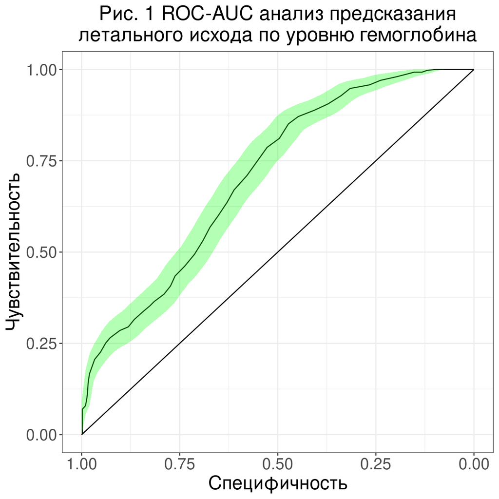

```r
# Небольшой костыль для визуализации диагональной линии (тест монетки)
diagonal <- data.frame(x=c(0,1),
                          y=c(1,0))

# Эти 3 строчки -- заимствование кода из источника выше
ciobj <- ci.se(roc_hb_death, specificities=seq(0, 1, l=100))
dat.ci <- data.frame(x = as.numeric(rownames(ciobj)),
                     lower = ciobj[, 1],
                     upper = ciobj[, 3])

roc_hb_death %>%
  ggroc() +
  geom_path(data=diagonal,
            aes(x=x, y=y))+
  theme_bw()+
  labs(x = "Специфичность",
     y = "Чувствительность",
     title = "Рис. 1 ROC-AUC анализ предсказания\nлетального исхода по уровню гемоглобина")+
  theme(axis.text.x = element_text(size=16),
        axis.text.y = element_text(size=16),
        axis.title.x = element_text(size=19),
        axis.title.y = element_text(size=19),
        plot.title = element_text(size=20, hjust=0.5))+
  geom_ribbon(data = dat.ci,
              aes(x = x,
                  ymin = lower,
                  ymax = upper),
              fill = "green", alpha= 0.3)
```

Такая форма кривой – достаточно резкий “взлет” кривой в районе 100% специфичности и пологая линия около 100% чувствительности – может говорить о том, что крайние значения гемоглобина дают достаточно точный прогноз по выживаемости (очень маленькие – плохой, большие – хорошие), однако значения между ними с куда меньшим успехом предскажут верный исход. “Прилепленный” к нижней части диагонали фрагмент графика исчез после удаления нулей в данных по гемоглобину. Также можно наблюдать вогнутость кривой в нижнем фрагменте, что может быть связаны с половым диморфизмом распределения гемоглобина. Построим дополнительные кривые для мужчин и женщин, а затем сравним результат.

```r
roc_hb_death_m <- trauma %>%
  filter(Sex == "Male") %>%
  roc(Death ~ Hb, ., ci=TRUE)
roc_hb_death_m
```

```
##
## Call:
## roc.formula(formula = Death ~ Hb, data = ., ci = TRUE)
##
## Data: Hb in 385 controls (Death Survived) > 247 cases (Death Doesn't survived).
## Area under the curve: 0.8198
## 95% CI: 0.7872-0.8524 (DeLong)
```

```r
roc_hb_death_f <- trauma %>%
  filter(Sex == "Female") %>%
  roc(Death ~ Hb, ., ci=TRUE)
roc_hb_death_f
```

```
##
## Call:
## roc.formula(formula = Death ~ Hb, data = ., ci = TRUE)
##
## Data: Hb in 220 controls (Death Survived) > 156 cases (Death Doesn't survived).
## Area under the curve: 0.8177
## 95% CI: 0.7755-0.86 (DeLong)
```

Заметим, что при разделении по данному фактору мы увеличили AUC до значений близких к `82%` в обоих случаях. Гипотетически это может говорить о конфаундинге по полу (мы точно знаем о меньшем уровне гемоглобина у женщин, а связь со смертностью может быть, например, чисто умозрительно обосновано “более рискованным стилем вождения самоката у мужчин”).

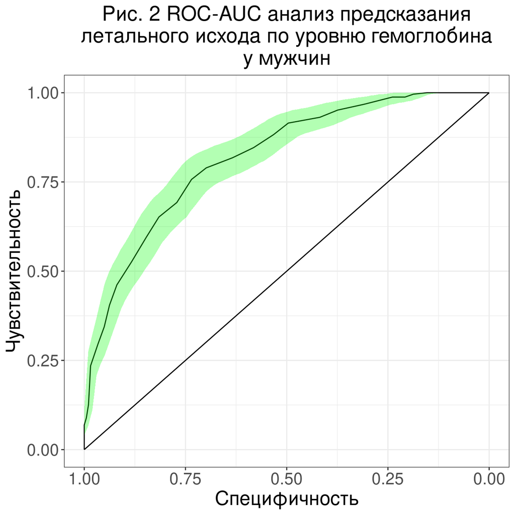

```r
ciobj <- ci.se(roc_hb_death_m, specificities=seq(0, 1, l=100))
dat.ci <- data.frame(x = as.numeric(rownames(ciobj)),
                     lower = ciobj[, 1],
                     upper = ciobj[, 3])

roc_hb_death_m %>%
  ggroc() +
  geom_path(data=diagonal,
            aes(x=x, y=y))+
  theme_bw()+
  labs(x = "Специфичность",
     y = "Чувствительность",
     title = "Рис. 2 ROC-AUC анализ предсказания\nлетального исхода по уровню гемоглобина\nу мужчин")+
  theme(axis.text.x = element_text(size=16),
        axis.text.y = element_text(size=16),
        axis.title.x = element_text(size=19),
        axis.title.y = element_text(size=19),
        plot.title = element_text(size=20, hjust=0.5))+
  geom_ribbon(data = dat.ci,
              aes(x = x,
                  ymin = lower,
                  ymax = upper),
              fill = "green", alpha= 0.3)
```

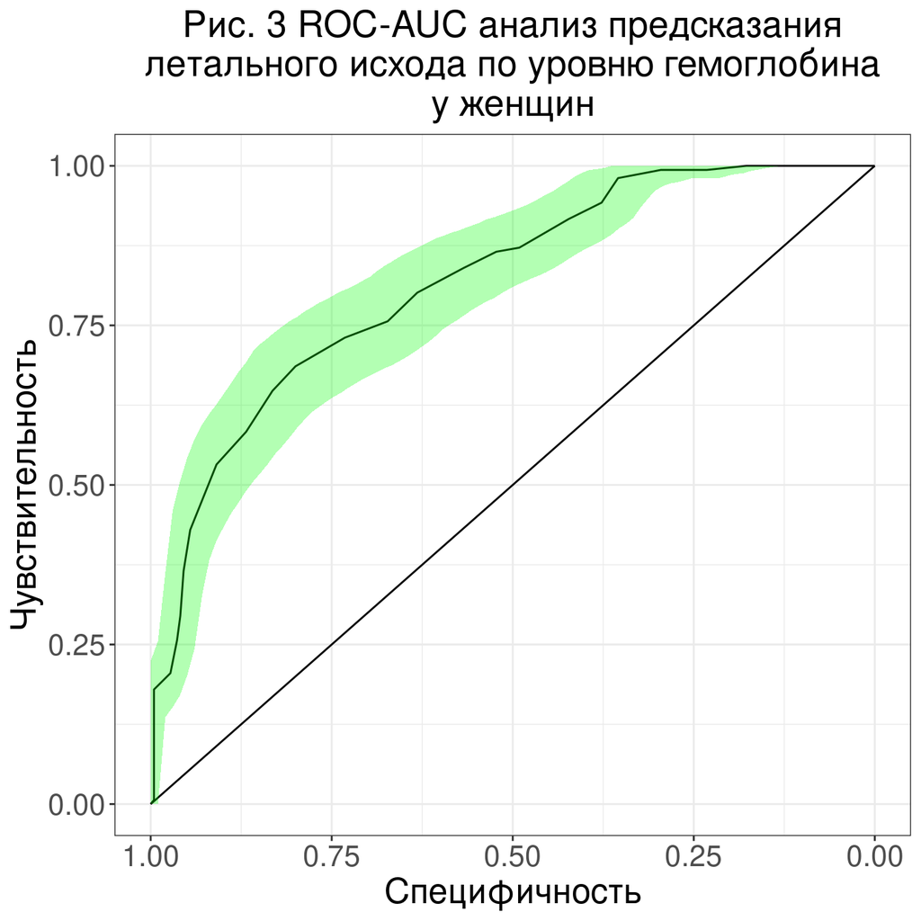

```r
ciobj <- ci.se(roc_hb_death_f, specificities=seq(0, 1, l=100))
dat.ci <- data.frame(x = as.numeric(rownames(ciobj)),
                     lower = ciobj[, 1],
                     upper = ciobj[, 3])

roc_hb_death_f %>%
  ggroc() +
  geom_path(data=diagonal,
            aes(x=x, y=y))+
  theme_bw()+
  labs(x = "Специфичность",
     y = "Чувствительность",
     title = "Рис. 3 ROC-AUC анализ предсказания\nлетального исхода по уровню гемоглобина\nу женщин")+
  theme(axis.text.x = element_text(size=16),
        axis.text.y = element_text(size=16),
        axis.title.x = element_text(size=19),
        axis.title.y = element_text(size=19),
        plot.title = element_text(size=20, hjust=0.5))+
  geom_ribbon(data = dat.ci,
              aes(x = x,
                  ymin = lower,
                  ymax = upper),
              fill = "green", alpha= 0.3)
```

У кривых по отдельности форма стала более пологой, при этом прямые участки в районе 100% чувствительности и специфичности сохранились и даже выросли, что свидетельствует о валидности предыдущего предположения о довольно точном прогнозе при маргинальных значениях гемоглобина. Некоторая “впуклость” кривой, да простится мне этот термин исчезает, что говорит о верности разбиения на два пола (на самом деле, информация об этом была получена из замечаний к первой итерации работы.)

## 5

> Примечание. Исходно я по ошибке посчитал все не для Глазго, а для гемоглобина. На случай, если это покажется нужным, оставляю расчеты и для него.

### Расчет для ШК Глазго

Поберем порог для наилучшего определения смертности в течение суток по баллу шкалы Глазго. Будем считать, что нам важен оптимальный баланс чувствительности и специфичности, а не что-то с уклоном в большую чувствительность/специфичность.

```r
roc_gsc_death <- trauma %>%
  roc(Death ~ GSC, ., ci=TRUE)

roc_gsc_death
```

```
##
## Call:
## roc.formula(formula = Death ~ GSC, data = ., ci = TRUE)
##
## Data: GSC in 605 controls (Death Survived) > 403 cases (Death Doesn't survived).
## Area under the curve: 0.9129
## 95% CI: 0.8963-0.9295 (DeLong)
```

```r
roc_gsc_death %>%
  coords(x = "best", best.method = "closest.topleft") %>% round(3)
```

```
##   threshold specificity sensitivity
## 1       7.5       0.808       0.856
```

Попробуем иной подход.

```r
roc_gsc_death %>%
  coords(x = "best", best.method="youden") %>% round(3)
```

```
##   threshold specificity sensitivity
## 1       7.5       0.808       0.856
```

Результат аналогичен и для метода *Youden*.

### Расчет для гемоглобина

Поберем порог для наилучшего определения смертности в течение суток по уровню гемоглобина. Будем считать, что нам важен оптимальный баланс чувствительности и специфичности, а не что-то с уклоном в большую чувствительность/специфичность.

```r
roc_hb_death %>%
  coords(x = "best", best.method = "closest.topleft") %>% round(3)
```

```
##   threshold specificity sensitivity
## 1     13.15       0.612        0.67
```

[figure not shown]

Идеальный баланс

Попробуем другой подход.

```r
roc_hb_death %>%
  coords(x = "best", best.method="youden") %>% round(3)
```

```
##   threshold specificity sensitivity
## 1     13.65       0.473       0.851
```

## 6

Проверим, какой из параметров обладает наибольшей ROC-AUC.

```r
# Исключаем айди, так как эта переменная, вероятнее всего, не несет медицинского смысла
trauma %>%
  select(where(is.numeric) & !id | Death) %>%
  pivot_longer(cols = !Death, names_to = "Variable") %>%
  group_by(Variable) %>%
  summarise(AUC = roc(Death, value, ci = T)$ci[2] %>% round(2),
              AUC_lCI = roc(Death, value, ci = T)$ci[1] %>% round(2),
              AUC_uCI = roc(Death, value, ci = T)$ci[3] %>% round(2))
```

```
## # A tibble: 9 × 4
##   Variable   AUC AUC_lCI AUC_uCI
##   <chr>    <dbl>   <dbl>   <dbl>
## 1 Age       0.53    0.49    0.56
## 2 BMI       0.5     0.47    0.54
## 3 DBP       0.74    0.71    0.77
## 4 FOUR      0.93    0.92    0.95
## 5 GSC       0.91    0.9     0.93
## 6 Hb        0.71    0.68    0.74
## 7 Height    0.48    0.44    0.52
## 8 SBP       0.78    0.76    0.81
## 9 Weight    0.48    0.44    0.51
```

Лучшие результаты показали две шкалы ком. Это выглядит логичным с той точки зрения, что они являются интергративным показателем общей тяжести состояния (а не только снижения концентрации эритроцитов, как в случае с уровнем гемоглобина).

Худшие результаты показали рост, масса тела, ИМТ и возраст. У всех перечисленных параметров доверительный интервал площади под кривой включает 0.5, что означает, что предсказательная сила теста весьма близка к столь любимому статистиками методу, как подбрасывание монетки. Ситуация с ростом, массой тела и производной от них вполне объяснима, поскольку прогноз обусловлен в первую очередь тяжестью состояния, а не антропометрией. Ситуация с возрастом выглдяит более неожиданно, поскольку интуитивно существует гипотеза о том, что при одинаковых по тяжести повреждениях вероятность выжить выше у более молодых пациентов.

Попробуем дополнительно разбить пациентов на возрастные группы (молодые и зрелые по ВОЗ [да, я помню о ненаходимой, но всеми используемой классификации, но для быстрого решения отсечка в 45 лет выглядит вполне удобной]) и посмотреть на ROC-AUC в каждой из них.

```r
age_roc <- trauma %>%
  select(Age, Death) %>%
  mutate(Age_group = case_when(
    Age < 45  ~ "Young",
    Age >= 45 ~ "Not so young"
  )) %>%
  group_by(Age_group) %>%
  summarise(AUC = roc(Death, Age, ci = T)$ci[2] %>% round(2),
              AUC_lCI = roc(Death, Age, ci = T)$ci[1] %>% round(2),
              AUC_uCI = roc(Death, Age, ci = T)$ci[3] %>% round(2)) %>%
  ungroup()
```

```r
age_roc
```

```
## # A tibble: 2 × 4
##   Age_group      AUC AUC_lCI AUC_uCI
##   <chr>        <dbl>   <dbl>   <dbl>
## 1 Not so young  0.5     0.44    0.55
## 2 Young         0.51    0.46    0.56
```

Нет, интуиция говорит нам ложные вещи. Внутри каждой из подгрупп мы снова получаем информацию об абсолютно неинформативном прогностическом значении возраста (ожидалось, что в старшей возрастной группе мы можем получить что-либо более интересное, но нет).